# Project Description

Pharmaceutical drugs play a very important role in maintaining our health. Because of this, it is crucial that these drugs are safe and cause little or no harmful side effects.

In this project, we create independent reports on drug safety, without relying on the drug manufacturers. We will perform several hypothesis tests using Python to find out if the adverse reactions to a hypothetical drug are significant. We will also investigate whether factors like age have a significant effect on these adverse reactions.

The dataset we use contains information about five specific adverse effects, as well as demographic data, vital signs, and other measurements. Our main focus is on the drug’s adverse reactions, and we want to understand if these reactions occur in significant numbers.

The dataset, named `drug_safety.csv`, was obtained from [Hbiostat](https://hbiostat.org/data/), provided by the Vanderbilt University Department of Biostatistics. It includes five adverse effects: headache, abdominal pain, dyspepsia, upper respiratory infection, and chronic obstructive airway disease (COAD). The dataset also contains demographic details, vital signs, lab measurements, and more. The number of drug-treated observations is twice the number of placebo observations.

For this project, the dataset has been modified to show two key variables: `adverse_effects`, which indicates whether an individual had any adverse effects, and `num_effects`, which counts how many adverse effects each individual experienced.

The modified dataset includes the following columns:

| Column | Description |
| --- | --- |
| `sex` | The gender of the individual |
| `age` | The age of the individual |
| `week` | The week during which the drug testing took place |
| `trx` | The treatment group (Drug) or control group (Placebo) |
| `wbc` | White blood cell count |
| `rbc` | Red blood cell count |
| `adverse_effects` | Whether the individual experienced at least one adverse effect |
| `num_effects` | The total number of adverse effects experienced by the individual |

The original dataset is available [here](https://hbiostat.org/data/repo/safety.rda). In this project, we will explore the data and answer important questions related to drug safety and adverse effects.

```python
# import the required libraries
import numpy as np
import pandas as pd
from statsmodels.stats.proportion import proportions_ztest
import pingouin
import seaborn as sns
import matplotlib.pyplot as plt
```

```python
# load the dataset
drug_safety = pd.read_csv('drug_safety.csv', usecols = lambda col: col != 'index')
drug_safety.head()
```

|  | age | sex | trx | week | wbc | rbc | adverse_effects | num_effects |
| --- | --- | --- | --- | --- | --- | --- | --- | --- |
| 0 | 62 | male | Drug | 0 | 7.3 | 5.1 | No | 0 |
| 1 | 62 | male | Drug | 1 | NaN | NaN | No | 0 |
| 2 | 62 | male | Drug | 12 | 5.6 | 5.0 | No | 0 |
| 3 | 62 | male | Drug | 16 | NaN | NaN | No | 0 |
| 4 | 62 | male | Drug | 2 | 6.6 | 5.1 | No | 0 |

### Determine if the proportion of adverse effects differs significantly between the Drug and Placebo groups

```python
# Count the adverse_effects column values for each trx group
adv_eff_by_trx = drug_safety.groupby("trx").adverse_effects.value_counts()
adv_eff_by_trx
```

```
trx      adverse_effects
Drug     No                 9703
         Yes                1024
Placebo  No                 4864
         Yes                 512
Name: count, dtype: int64
```

```python
# Count the number of total rows in each group
adv_eff_by_trx_totals = adv_eff_by_trx.groupby("trx").sum()
adv_eff_by_trx_totals
```

```
trx
Drug       10727
Placebo     5376
Name: count, dtype: int64
```

```python
# Create an array of the "Yes" counts for each group
yeses = [adv_eff_by_trx["Drug"]["Yes"], adv_eff_by_trx["Placebo"]["Yes"]]
yeses
```

```
[1024, 512]
```

```python
# Create an array of the total number of rows in each group
n = [adv_eff_by_trx_totals["Drug"], adv_eff_by_trx_totals["Placebo"]]
n
```

```
[10727, 5376]
```

```python
# Perform a two-sided z-test on the two proportions
two_sample_results = proportions_ztest(yeses, n)
two_sample_results
```

```
(0.0452182684494942, 0.9639333330262475)
```

```python
# Extract the p-value
two_sample_p_value = two_sample_results[1]
two_sample_p_value
```

```
0.9639333330262475
```

### Find out if the number of adverse effects is independent of the treatment and control groups

```python
# Determine if num_effects and trx are independent
num_effects_groups = pingouin.chi2_independence(
    data=drug_safety, x="num_effects", y="trx")

# Extract the p-value
num_effects_p_value = num_effects_groups[2]["pval"][0]

num_effects_p_value
```

```
0.6150123339426765
```

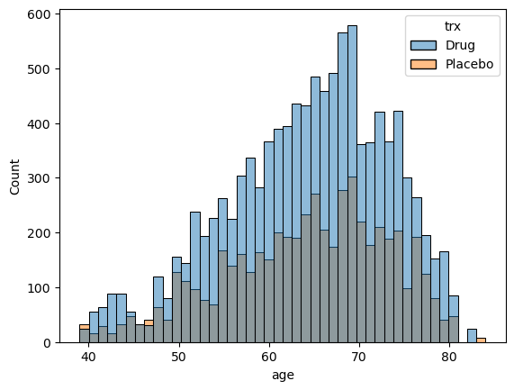

```python
# Create a histogram
sns.histplot(data=drug_safety, x="age", hue="trx")
```

```python
# confirm the histogram's output by conducting a normality test, To choose between unpaired t-test and Wilcoxon-Mann-Whitney test
normality = pingouin.normality(
    data=drug_safety,
    dv='age',
    group='trx',
    method='shapiro', # the default
    alpha=0.05) # 0.05 is also the default

normality
```

| trx | W | pval | normal |
| --- | --- | --- | --- |
| Drug | 0.976785 | 2.189152e-38 | False |
| Placebo | 0.975595 | 2.224950e-29 | False |

```python
# Select the age of the Drug group
age_trx = drug_safety.loc[drug_safety["trx"] == "Drug", "age"]

# Select the age of the Placebo group
age_placebo = drug_safety.loc[drug_safety["trx"] == "Placebo", "age"]


# Since the data distribution is not normal, lets conduct a two-sided Mann-Whitney U test
age_group_effects = pingouin.mwu(age_trx, age_placebo)

age_group_effects
```

|  | U-val | alternative | p-val | RBC | CLES |
| --- | --- | --- | --- | --- | --- |
| MWU | 29149339.5 | two-sided | 0.256963 | 0.01093 | 0.505465 |

```python
# Extract the p-value
age_group_effects_p_value = age_group_effects["p-val"]
age_group_effects_p_value
```

```
MWU    0.256963
Name: p-val, dtype: float64
```

## Final Summary

The Drug does not cause more side effects than the Placebo (p-value = 0.9639).

The number of side effects is not related to the Drug or Placebo group (p-value = 0.6150).

The Drug and Placebo groups do not have a significant age difference (p-value = 0.2569).

**This suggests that the Drug is just as safe as the Placebo because the side effects are similar in both groups.**